# ES207- Lab2

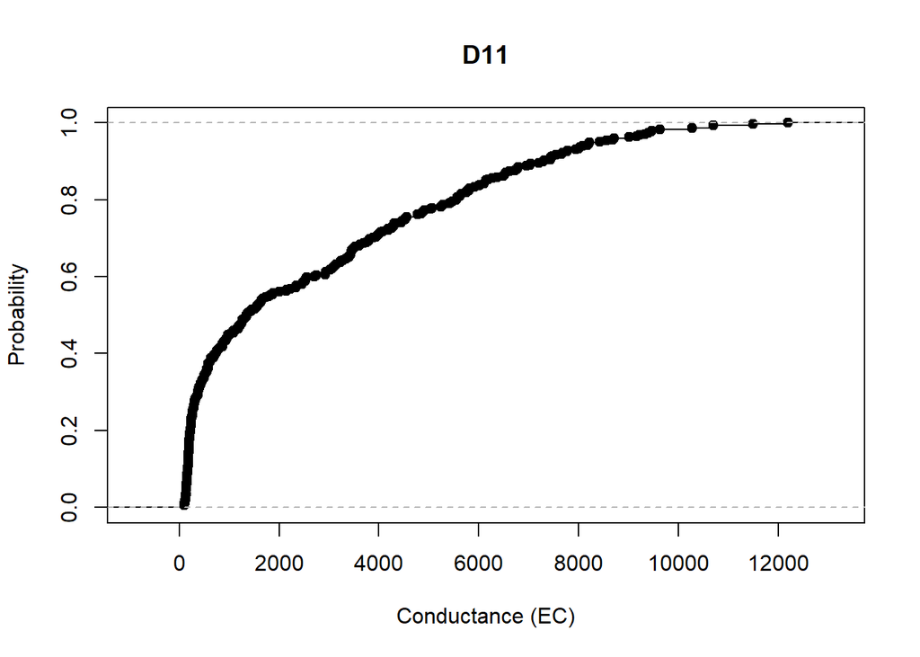

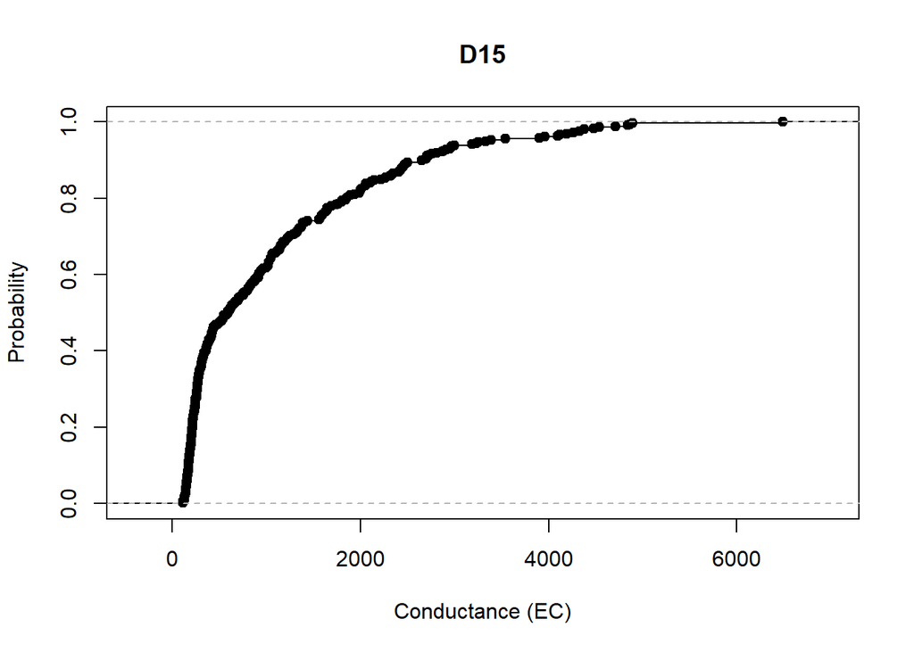

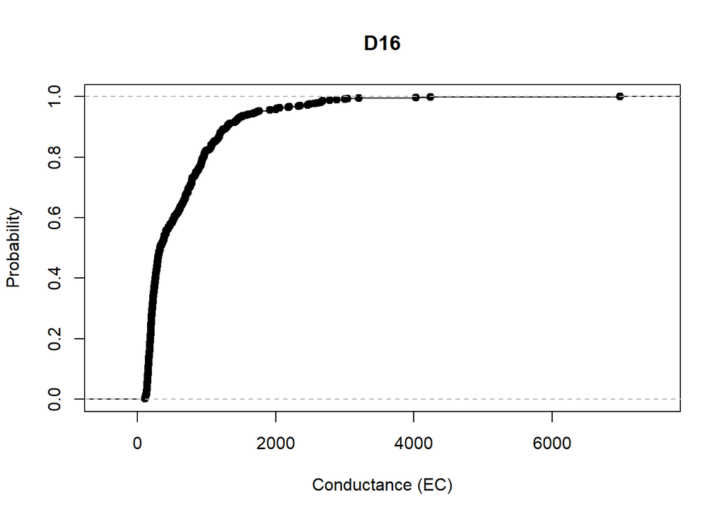

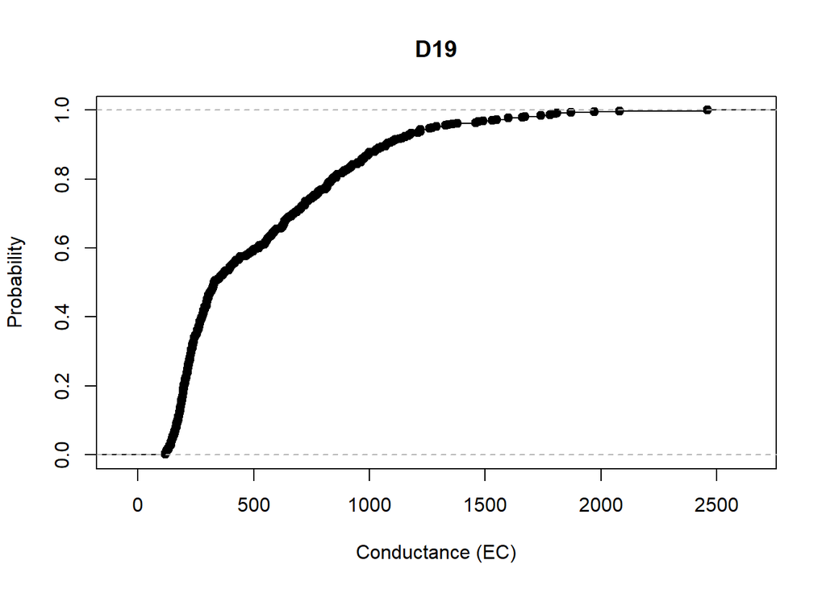

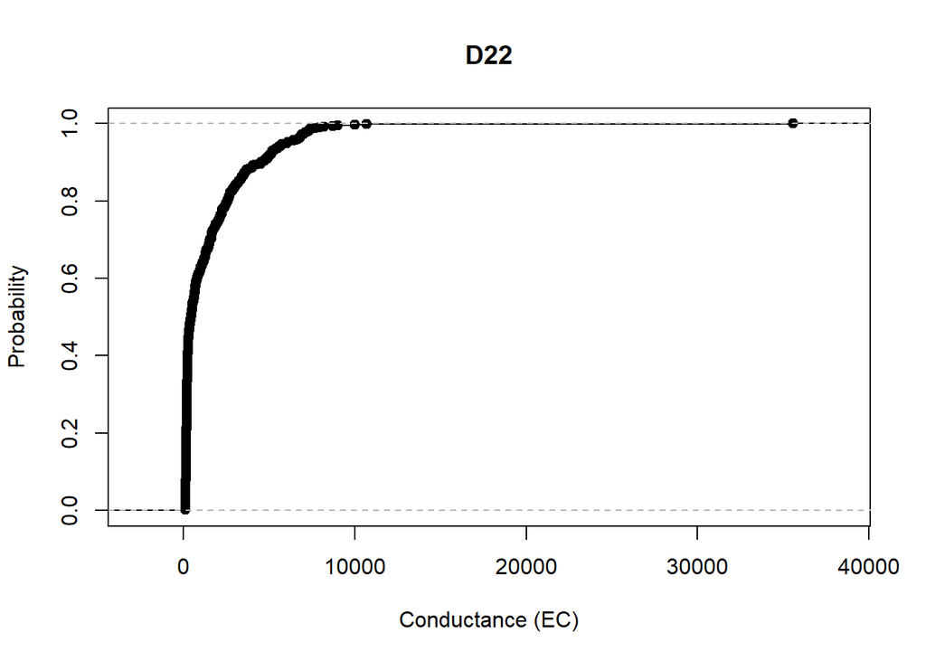

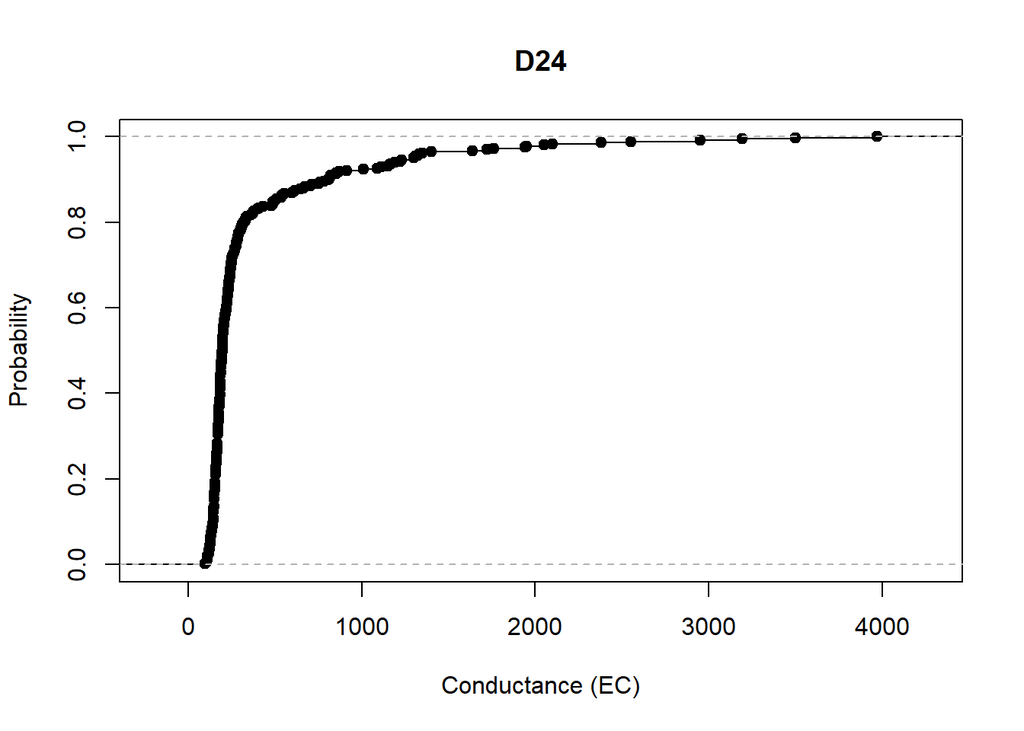

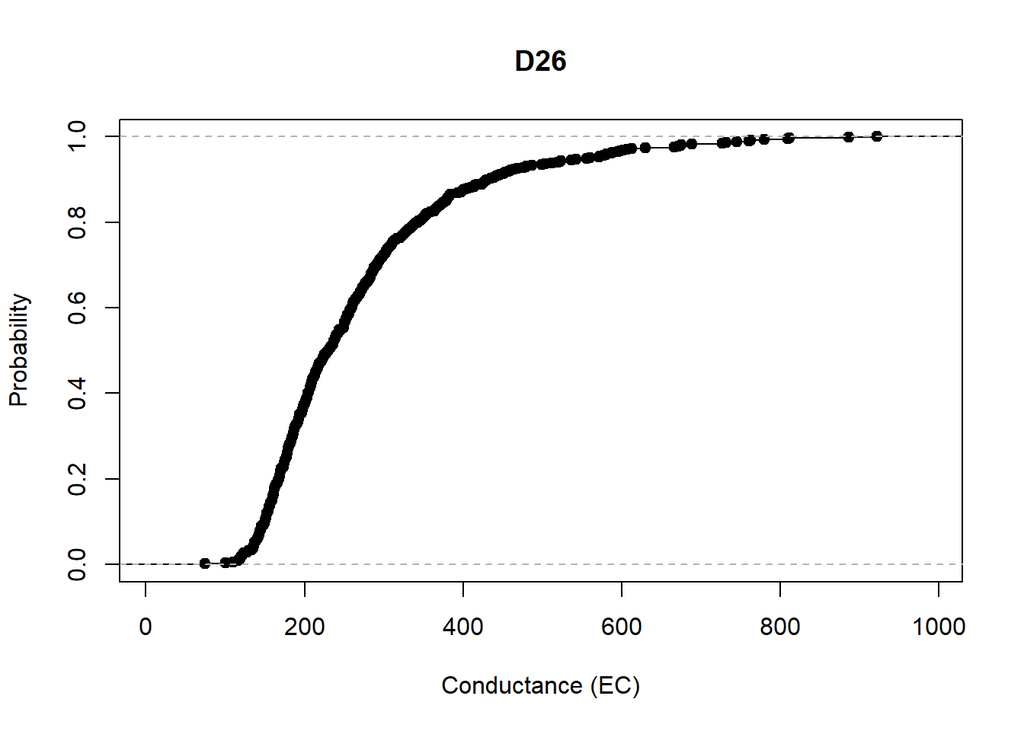

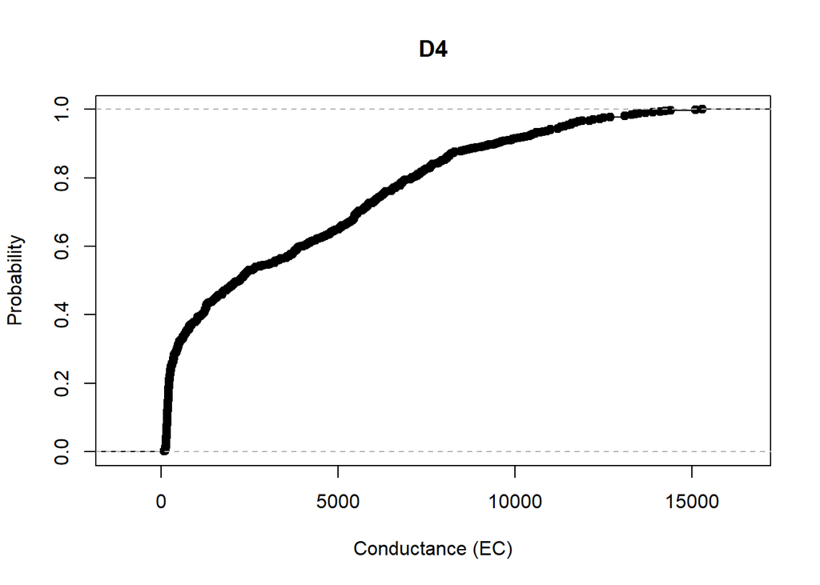

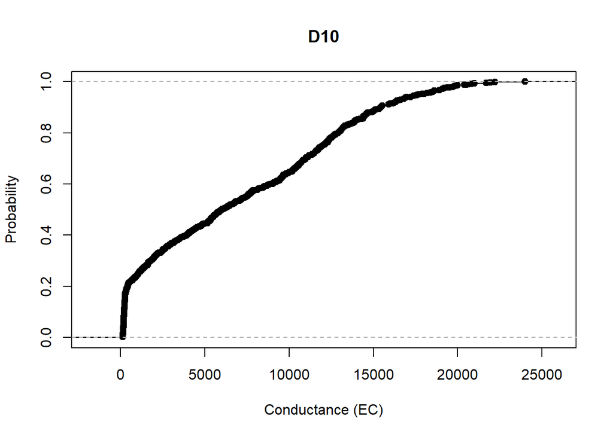

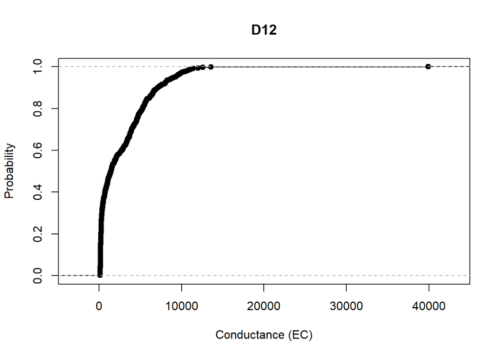

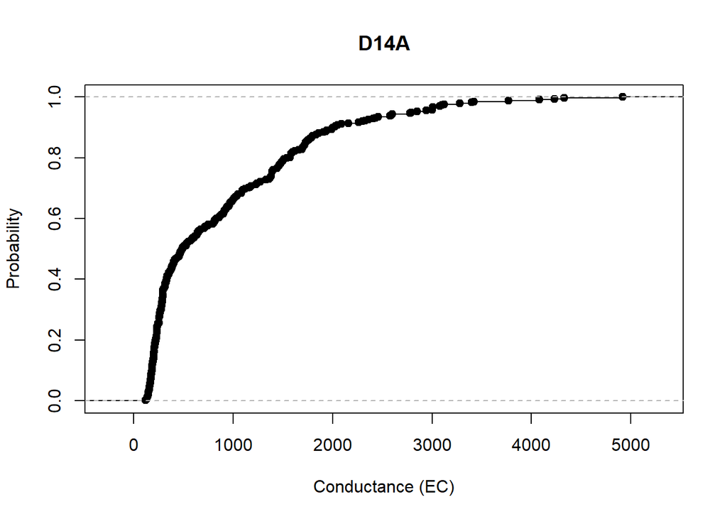

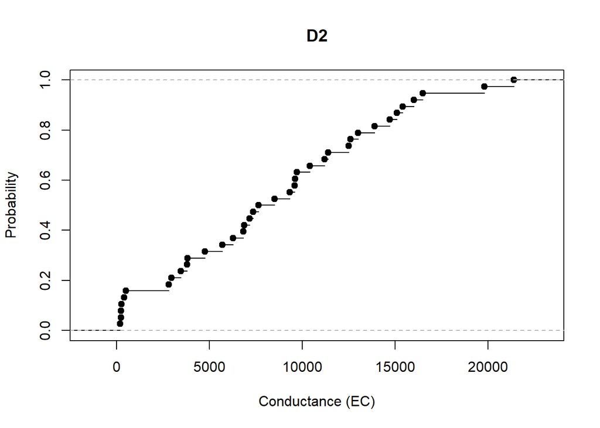

[39 more figures not shown]

```r
## cummulative density plot
sites <- unique(wQ$StationCode)
try(for (i in 1:length(sites)){
   mySub <- subset(wQ,StationCode == sites[i] ,select = `Conductance (EC)` )
    cdf_fun <- ecdf(mySub$`Conductance (EC)`)
    plot(cdf_fun, xlab = "Conductance (EC)", ylab = "Probability", main = sites[i])
})
```

**7. Compare the mercury concentrations from the station with the highest concentration and the lowest concentration using a Q-Q plot. Also plot two other types of graphs. Describe the similarities and differences in Mercury. What characteristics are evidet in each graph?**

If we look at a frequence plot of all Mercury data we can see that there is no station with the highest [hg] or lowest [hg]. From these plots we can see two things, 1) There is no single station or pair of stations to select 2) Excluding NA’s, there are only 4 values avaliable for mercury concentration: 0.1,0.2,0.3,1.0. Several of the stations, such as P10 only have one value of mercury recorded, which is problematic seeing as a QQPlot is used to check the validity of a distribution (normal QQ for normal distibution) assumption for a given dataset . Therefore, in cases were there is only one value for a given station the QQplot would confirm that the data is not normally distributed. When you look at the QQplot it somewhat looks bi-modal with some very high values and some very low values spanning across the whole dataset. Additionally, you may want to group the stations by some other variable to get a better understand of what is going on. Perhaps location or year.

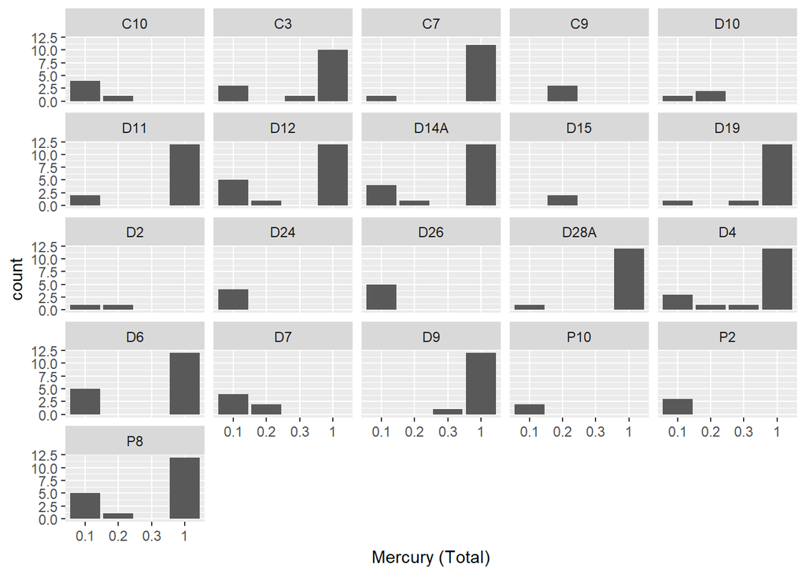

```r
## Historgram of all the stations together
# not  very effective to look at.
wQ %>%
  select(`Mercury (Total)`,StationCode) %>%
  na.omit() %>%
  ggplot(aes(`Mercury (Total)`)) +
    geom_histogram(stat ="count")+
      facet_wrap(~StationCode)
```

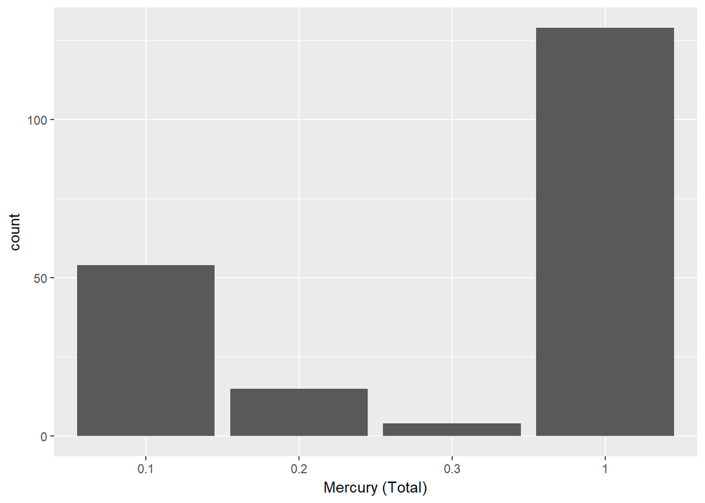

```r
# histrogram all data
wQ %>%
  select(`Mercury (Total)`,StationCode) %>%
  na.omit() %>%
  ggplot(aes(`Mercury (Total)`)) +
    geom_histogram(stat ="count")
```

```r
# Verify that some stations only have one value
wQ %>%
  filter(StationCode == "P10") %>%
  select(`Mercury (Total)`) %>%
  unique()
```

| Mercury (Total) |
| --- |
| NA |
| 0.1 |

Normally when there is somewhat of a break in the middle of the QQplot one would say that the data are bi-modal. how meaningful is that here?

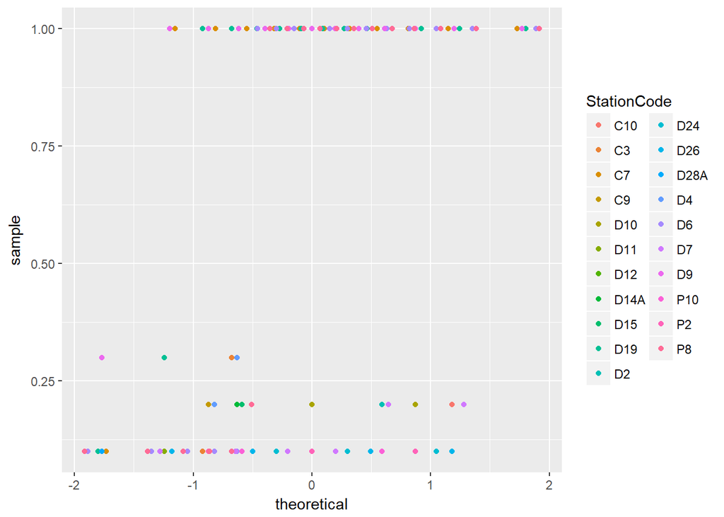

```r
## QQplot of all the stations
wQ %>%
  select(`Mercury (Total)`,StationCode) %>%
  ggplot(mapping = aes(sample = as.numeric(`Mercury (Total)`), col = StationCode)) +
  stat_qq()
```

```r
#group_by(StationCode) %>%
```

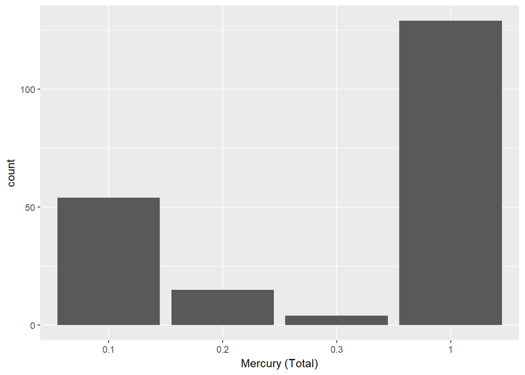

```r
# histogram of all the stations together
wQ %>%
  select(`Mercury (Total)`,StationCode) %>%
  na.omit() %>%
  ggplot(aes(`Mercury (Total)`)) +
    geom_histogram(stat ="count")
```

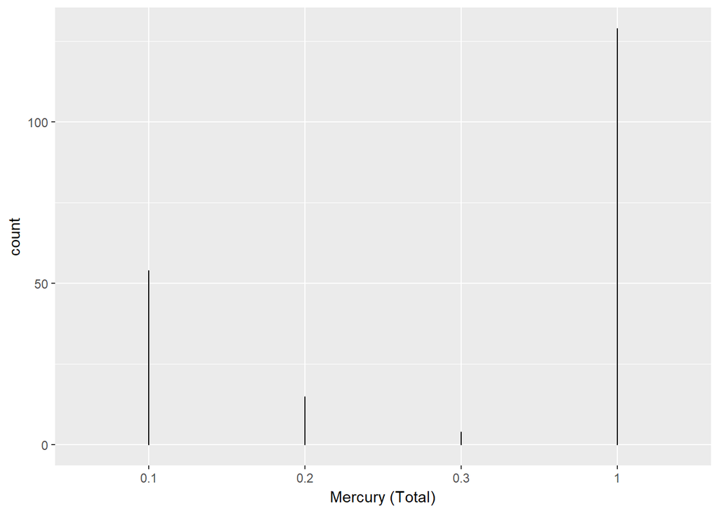

```r
# if we try to make a denisty plot which will use a guassian kernel to smooth the data by default
# there is no smoothing.
wQ %>%
  select(`Mercury (Total)`,StationCode) %>%
  na.omit() %>%
  ggplot(aes(`Mercury (Total)`)) +
    geom_density(stat ="count")
```

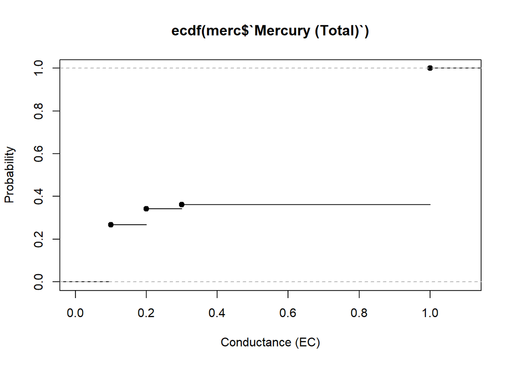

```r
## cummulative

merc <- wQ %>%
  select(`Mercury (Total)`,StationCode) %>%
  na.omit()

cdf_fun <- ecdf(merc$`Mercury (Total)`)
plot(cdf_fun, xlab = "Conductance (EC)", ylab = "Probability")
```

#### random notes to self … ignore

- distriubtion linear space linear distributed
- you know it its skewed high and low
- you see if it is high and low
- plot by date: difference in method
- is mercury increasing over time
- continuous data
- 78-88 - drought, el nino 82/83 el nino
- not all the time series are complete in the dataset